# Stat 202: Lecture 15 (covers pp. 166-169)

Nathan VanHoudnos  
10/29/2014

### Agenda

1. Checkpoint #16 comments
2. Lecture 15 (covers pp. 166-169)

### Agenda

1. Checkpoint #16 comments
2. Lecture 15 (covers pp. 166-169)

### Stat 202 focuses on

Population Parameters

**Continuous**

- Population mean: \( \mu \)
- Population standard deviation: \( \sigma \)

Categorical

- Population proportion: \( p \)

Sample Statistics

**Continuous**

- Sample mean: \( \bar{x} \)
- Sample standard deviation: \( s \)

Categorical

- Sample proportion: \( \hat{p} \)

### Height of Adult males

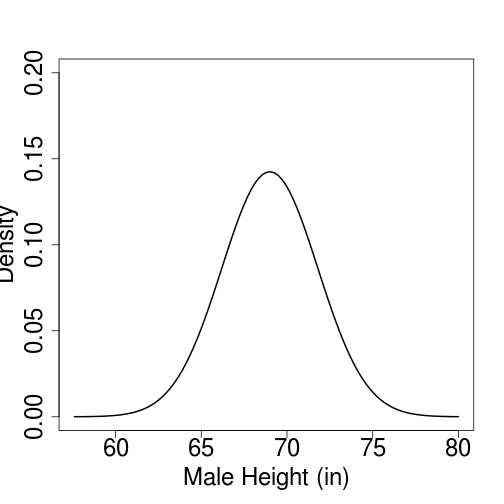

Assume that the height of adult men is normally distributed with a mean of 69 in. and a standard deviation of 2.8 in.

### Height of Adult males

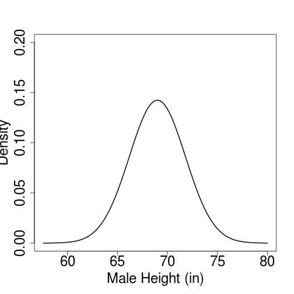

Assume that the height of adult men is normally distributed with a mean of 69 in. and a standard deviation of 2.8 in.

- Randomly select 15 men from the population and measure their heights:

```
67.2 69.5 66.7 73.5 69.9 66.7 70.4 71.1 70.6 68.1 73.2 70.1 67.3 62.8 72.1
```

### Height of Adult males

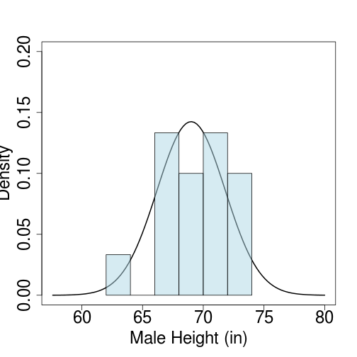

Assume that the height of adult men is normally distributed with a mean of 69 in and a standard deviation of 2.8 inches.

- Randomly select 15 men from the population and measure their heights:
- Make a histogram of those randomly selected 15 men.

### Sample mean of Adult Males

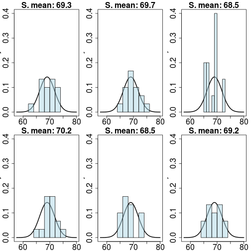

The **population** mean

- always 69 inches.

Each **sample** mean

```
69.3 69.7 68.5 70.2 68.5 69.2
```

### Sample 15 men 1,000 times

```
69.3 69.7 68.5 70.2 68.5 69.2 70.6 67.9 69.1 68.7 67.8 67.6 69.3 70.6 69.5 69.9 70.2 69.1 69.2 68.1 69.1 69.7 69.9 68.5 67.7 69.8 69.6 68.2 69.5 68.2 68.9 69.5 69.3 69.3 69.6 69.3 69.8 68.5 68.6 68.2 69.8 70.4 68.5 67.6 69.1 69.7 68.4 70.2 68.7 68.6 68.7 68.8 69.2 70 68 68.9 69.7 68.6 69.6 68.7 68.4…
```

### A histogram of the sample means

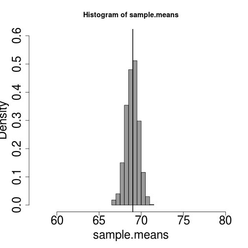

- Randomly select 15 men from the population and measure their heights.
- Do this 1,000 times
- The distribution of the sample mean is close to the population mean (69 inches)

### What if we took 50 men instead?

**Average of 15 men**

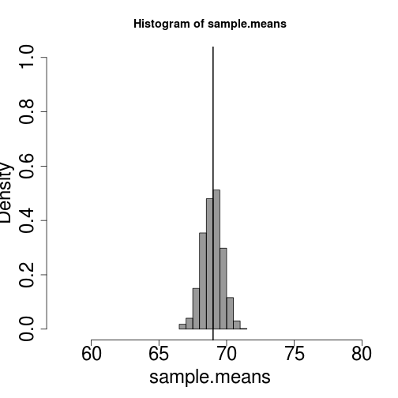

**Average of 50 men**

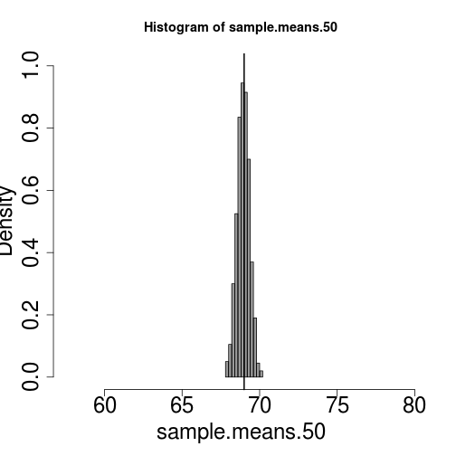

### Approximately normal (which?)

If \( X \) is normally distributed with mean \( \mu \) and variance \( \sigma^2 \)

\[ X \sim N( \mu, \sigma^2) \]

then the mean of a sample of \( n \) **indepedent** draws from \( X \)

\[ \bar{x} = \frac{1}{n} \left[x_1 + x_2 + \dots x_n \right] \]

is also normally distributed

\[ \bar{x} \sim N\left( \mu, \frac{\sigma^2}{n} \right) \]

### If X is normal, then

\[ \begin{aligned} \bar{x} & = \frac{1}{n} \left[x_1 + x_2 + \dots x_n \right] & & & \bar{x} & \sim N\left( \mu, \frac{\sigma^2}{n} \right) \end{aligned} \]

**Proof**

1. The sum of two (or more) independent normal random variables is also normally distributed.
2. A normal distribution is defined by its mean and variance.

\[ \bar{x} \sim N\left( E[\bar{x}], \text{Var}[\bar{x}] \right) \]

so find \( E[\bar{x}] \) and \( \text{Var}[\bar{x}] \) (on the board.)

### Example 2: Radioactive Decay

(for scale)

Bananas are [radioactive](http://en.wikipedia.org/wiki/Banana_equivalent_dose).

- In one gram of banana, 31 atoms of potassium-40 will decay every second.
- In a 150 gram banana \[ 150 * 31 = 4,650 \] decay events happen per second.

### Example 2: Radioactive Decay

**Time between decays**

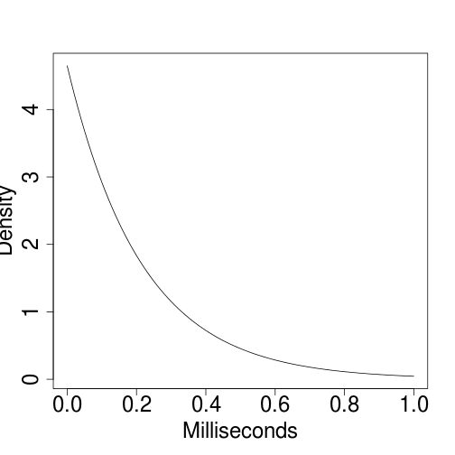

The time between radioactive decay events follows an **exponential distribution**.

- A large proportion of events happen quickly.
- Rarely, you have to wait awhile for an event.
- The wait times are independent of each other.

### Example 2: Radioactive Decay

**Time between decays**

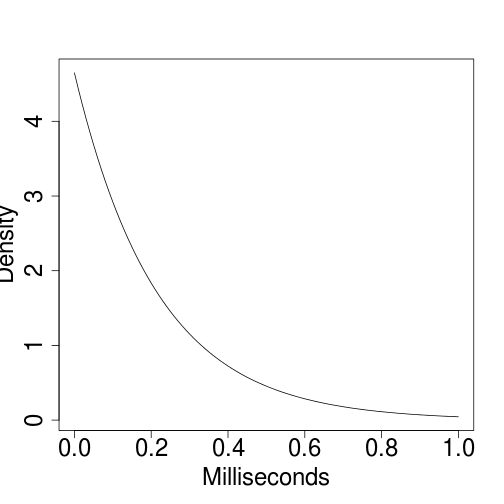

Let's wait for a decay event and record the time it took:

```
0.162
```

And again:

```
0.254
```

And do this 50 times to make a histogram…

### Example 2: Radioactive Decay

**Time between decays**

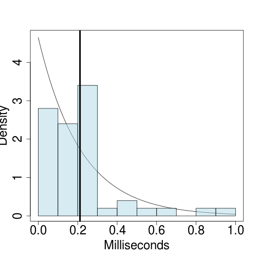

The **time between decay events** follows an exponential distribution.

For this sample, from this banana, the average wait time between events was

```r
mean(draw50.1)
```

```
[1] 0.2116219
```

milliseconds.

### Example 2: Radioactive Decay

**Time between decays**

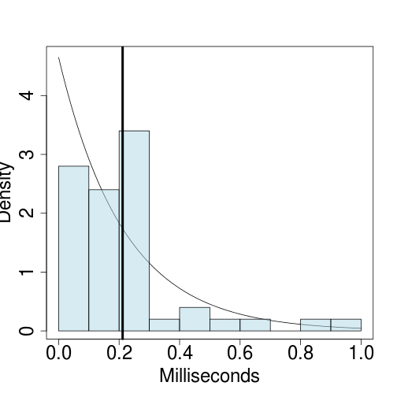

The **time between decay events** follows an exponential distribution.

> If we repeated this experiment with, say 1,000, additional bananas, what would the sampling distribution of the mean look like?

### More Bananas

- Banana 1: Collect data for 50 events. Calculate the mean.

```
0.212
```

- Banana 2: Collect data for 50 events. Calculate the mean.

```
0.24
```

- …
- Banana 1000: Collect data for 50 events. Calculate the mean.

```
0.185
```

### Something amazing is coming

*Wait for it.*

### Banana denouement

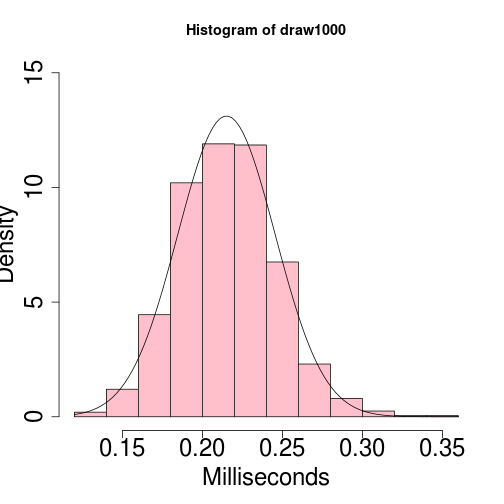

The average wait time of 50 events is approximately

**NORMALLY DISTRIBUTED**

even though the distribution of the time between events looked **nothing** like a normal distribution.

### Bananas together

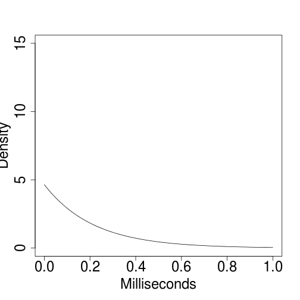

- The wait time is distributed as an exponential distribution.

### Bananas together

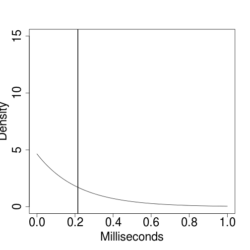

- The wait time is distributed as an exponential distribution.
- The theoretical (population) mean wait time is 0.215 milliseconds

### Bananas together

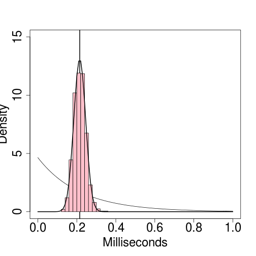

- The wait time is distributed as an exponential distribution.
- The theoretical (population) mean wait time is 0.215 milliseconds
- The sample mean of 50 events is **normally distributed** around 0.215 milliseconds.

### The central limit theorem (CLT)

1. Draw \( n \) **independent** samples from a distribution with a mean of \( \mu \) and a standard deviation of \( \sigma \).
2. Calculate the sample mean \( \bar{x} = \frac{x_1 + x_2 + \dots + x_n}{n} \).
3. **CLT**: If \( n \ge 30 \), then for **any distribution** that you will encounter in practice, the **sample mean** is **normally distributed** with a mean of \( \mu \) and a standard deviation of \( \frac{\sigma}{\sqrt{n}} \).

\[ n \ge 30 \quad \Rightarrow \quad \bar{x} \sim N \left( \mu, \frac{\sigma^2}{n} \right) \]

### Sir Francis Galton

Inventor of Regression

1822-1911

From [Three-Toed Sloth](http://vserver1.cscs.lsa.umich.edu/%7Ecrshalizi/weblog/390.html):

> I know of scarcely anything so apt to impress the imagination as the wonderful form of cosmic order expressed by **the law of error**. A savage, if could understand it, would worship it as a god.

### Back to bananas

(for scale)

Which of the following are normally distributed?

The average wait time calculated from 5 events,

1. with no repetitions.
2. repeated for 30 bananas.
3. repeated for 1,000 bananas.

**None.** \( n = 5 \) for all cases. CLT is about the average of a large sample (\( n \ge 30 \)), not a large number of averages.

### Back to bananas

1000 averages of \( n=5 \)

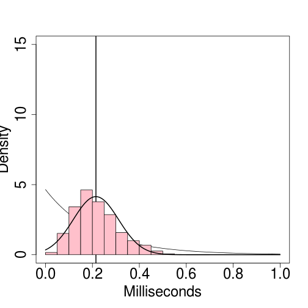

- The CLT does not apply for \( n = 5 \).
- The histogram does not match the theoretical normal distribution.

### Back to bananas

(for scale)

Which of the following are normally distributed?

The average wait time calculated from 50 events,

1. repeated for 100 bananas.
2. repeated for 10 bananas.
3. with no repetitions (just 1 banana).

**All.** \( n = 50 \) for all cases. CLT is about the average of a large sample (\( n \ge 30 \)), not a large (or small!) number of averages.

### Using the CLT

My father-in-law is a [potato farmer](http://www.wongpotatoes.com/aboutus.html):

[figure not shown]

### Using the CLT

**Klamath Pearls**

A small potato grown only in the Klamath Basin (near the OR/CA border)

- Like any potato, Klamath Pearls vary in size.
- Assume that the average size of a Klamath Pearl is 50 grams with a standard deviation of 10 grams.
- Note: the size of potatoes **does not** follow a normal distribution.

### Using the CLT

**Klamath Pearls**

Average size is 50 grams with a standard deviation of 10 grams.

Dan has a packing machine that puts potatoes into 1 lbs (450 g) and 5 lbs (2,250 g) bags.

- the “1 lbs” bag has approximately 9 potatoes in it.
- the “5 lbs” bag has approximately 45 potatoes in it.

### Using the CLT

**Klamath Pearls**

Average size is 50 grams with a standard deviation of 10 grams.

Dan is worried that one of his fields is producing smaller potatoes than it should be.

He grabs a “1 lbs” bag with 11 potatoes in it and calculates the (sample) average potato size.

Is the average potato size from a “1 lbs” bag normally distributed?

- **No.** \( n = 11 \)

### Using the CLT

**Klamath Pearls**

Average size is 50 grams with a standard deviation of 10 grams.

Dan is worried that one of his fields is producing smaller potatoes than it should be.

He grabs a “5 lbs” bag with 49 potatoes in it and calculates the (sample) average potato size.

Is the average potato size from a “5 lbs” bag normally distributed?

- **Yes.** \( n = 49 \)

### Using the CLT

**Klamath Pearls**

Average size is 50 grams with a standard deviation of 10 grams.

Dan picks a “5 lbs” bag with 49 potatoes in it. Its average potato weighs \( \bar{x} = 42 \) grams.

If the field is producing potatoes as it should, what is the probability that the average potato in this bag would weigh 42 grams or less?

### Using the CLT

The average size of a Klamath pearl is 50 grams with a standard deviation of 10 grams. Dan picks a “5 lbs” bag with 49 potatoes in it. Its average potato weighs \( \bar{x} = 42 \) grams. If the field is producing potatoes as it should, what is the probability that the average potato in this bag would weigh 42 grams or less?

Step 1. Identify population mean \( \mu \), population standard deviation \( \sigma \), sample size \( n \), and sample mean.

\( \mu = 50 \), \( \sigma = 10 \), \( n = 49 \), and \( \bar{x} = 42 \)

Step 2. Does the CLT apply?

**Yes.** \( n \ge 30 \) and each potato in the bag is likely independent.

### Using the CLT

If the field is producing potatoes as it should, what is the probability that the average potato in this bag would weigh at 42 grams or less? Recall: \( \mu = 50 \), \( \sigma = 10 \), \( n = 49 \), and \( \bar{x} = 42 \)

Step 3. Find the sampling distribution of \( \bar{x} \)

Recall: \( \bar{x} \sim N \left( \mu, \frac{\sigma^2}{n} \right) \) = \( N \left( 50, \frac{10^2}{49} \right) \)

i.e. a mean of 50 g and a standard deviation of \( \sqrt{\frac{10^2}{49}} = 1.43 \) grams.

### Using the CLT

If the field is producing potatoes as it should, what is the probability that the average potato in this bag would weigh 42 grams or less? Recall: \( \mu = 50 \), \( \sigma = 10 \), \( n = 49 \), \( \bar{x} = 42 \), and by CLT \( \bar{x} \sim N(50, 1.43^2) \).

Step 4. Answer the question.

\[ P( \bar{x} \le 42 ) \]

\[ = P( (\bar{x} - 50)/1.43 \le (42-50)/1.43 ) \\ = P(Z \le - 5.59) = 0 \]

The field **is not** producing potatoes properly.

### Summary

The **average** of something normally distributed is always normal.

The **average** of any independent draw greater than 30 is also always normal.